Water Quality Assessment Using Fuzzy Logic

```python
# Importing necessary libraries

import numpy as np
import pandas as pd

import matplotlib.pyplot as plt
import seaborn as sns

import skfuzzy as fuzz
from skfuzzy import control as ctrl

from IPython.display import Image, display

import warnings
warnings.filterwarnings('ignore')
```

# About the dataset

#### From: Central Ground Water Board (CGWB), Ministry of Jal Shakti, Department of Water Resources, River Development and Ganga Rejuvenation.

#### Description: Several Ground Water Quality parameters of locations across India in the year 2022.

#### Source: https://www.cgwb.gov.in/old_website/WQ/Water%20Quality/Water%20quality%20data%202022.pdf

```python
# Reading the dataset
df_org=pd.read_excel(r"D:\Data Science\Projects\3. Fuzzy Logic for Water Quality Assessment Project\Water quality data 2022.xlsx")
df_org.head()
```

|  | Sl_No | GEMS_ID W | STATE | DISTRICT | BLOCK | LOCATION | LONGITUDE | LATITUDE | Year | pH | ... | PO4 | TH | Ca | Mg | Na | K | F | SiO2 | TDS | U_ppb_ |
| --- | --- | --- | --- | --- | --- | --- | --- | --- | --- | --- | --- | --- | --- | --- | --- | --- | --- | --- | --- | --- | --- |
| 0 | 1 | W193530074180001 | Maharashtra | Ahmednagar | SANGAMNER | Kokangaon | 74.3 | 19.591667 | 2022 | 7.90 | ... | NaN | 465.0 | 80.2 | 64.4 | 88.3 | 1.6 | 0.53 | NaN | NaN | 2 |
| 1 | 2 | W192600074540001 | Maharashtra | Ahmednagar | NEVASA | Vadala Bhairoba | 74.9 | 19.433333 | 2022 | 7.55 | ... | NaN | 510.0 | 116.2 | 53.5 | 96.4 | 7.2 | 0.18 | NaN | NaN | 2 |
| 2 | 3 | W192400075180001 | Maharashtra | Ahmednagar | SHEVGAON | Ghotan | 75.3 | 19.4 | 2022 | 7.36 | ... | NaN | 1900.0 | 348.7 | 250.3 | 380.4 | 450.0 | 0.11 | NaN | NaN | 9 |
| 3 | 4 | W191640074134001 | Maharashtra | Ahmednagar | SANGAMNER | Bote | 74.227778 | 19.277778 | 2022 | 7.97 | ... | NaN | 425.0 | 76.2 | 57.1 | 87.7 | 2.1 | 0.31 | NaN | NaN | 1 |
| 4 | 5 | W193130073553001 | Maharashtra | Ahmednagar | AKOLA | Rajur | 73.925 | 19.525 | 2022 | 7.85 | ... | NaN | 290.0 | 50.1 | 40.1 | 15.7 | 0.3 | 0.20 | NaN | NaN | 1 |

5 rows × 26 columns

```python
df_org.shape
```

```
(13600, 26)
```

```python
df_org.info()
```

```
<class 'pandas.core.frame.DataFrame'>
RangeIndex: 13600 entries, 0 to 13599
Data columns (total 26 columns):
 #   Column        Non-Null Count  Dtype
---  ------        --------------  -----
 0   Sl_No         13600 non-null  int64
 1   GEMS_ID    W  11366 non-null  object
 2   STATE         13600 non-null  object
 3   DISTRICT      13600 non-null  object
 4   BLOCK         13520 non-null  object
 5   LOCATION      13600 non-null  object
 6   LONGITUDE     13600 non-null  object
 7   LATITUDE      13600 non-null  object
 8   Year          13600 non-null  int64
 9   pH            13600 non-null  float64
```

[output cut: 18 more lines]

```python
# Converting State and District names to all caps to avoid any discripancies
df_org["STATE"] = df_org["STATE"].str.upper()
df_org["DISTRICT"] = df_org["DISTRICT"].str.upper()
df_org.sample(5)
```

|  | Sl_No | GEMS_ID W | STATE | DISTRICT | BLOCK | LOCATION | LONGITUDE | LATITUDE | Year | pH | ... | PO4 | TH | Ca | Mg | Na | K | F | SiO2 | TDS | U_ppb_ |
| --- | --- | --- | --- | --- | --- | --- | --- | --- | --- | --- | --- | --- | --- | --- | --- | --- | --- | --- | --- | --- | --- |
| 6824 | 6825 | W11163177482901 | TAMIL NADU | NAMAKKAL | THIRUCHENGODU | Patlur | 77.8081 | 11.2753 | 2022 | 7.80 | ... | 0.0 | 310.0000 | 36.0 | 53.5 | 76.5 | 17.3 | 0.87 | NaN | NaN | 0 |
| 437 | 438 | W191846077135901 | MAHARASHTRA | HINGOLI | BASMATH | Palasgaon | 77.233056 | 19.312778 | 2022 | 7.73 | ... | NaN | 280.0000 | 52.1 | 36.5 | 49.9 | 2.2 | 0.77 | NaN | NaN | 3 |
| 1200 | 1201 | W191649072471101 | MAHARASHTRA | THANE | VASAI | Uttan | 72.786389 | 19.280278 | 2022 | 7.80 | ... | NaN | 320.0000 | 70.1 | 35.2 | 118.3 | 4.4 | 0.83 | NaN | NaN | 1 |
| 7598 | 7599 | W212105083500201 | ODISHA | BARGARH | ATTABIRA | Larambha | 83.833889 | 21.351389 | 2022 | 7.87 | ... | 0.0 | 194.0000 | 40.0 | 23.0 | 69.0 | 7.8 | 0.70 | NaN | NaN | 0 |
| 12016 | 12017 | NaN | PUNJAB | BATHINDA | Rampura phul | Dhapali | 75.242 | 30.363 | 2022 | 8.25 | ... | 0.0 | 52.0416 | 17.0 | 2.5 | 49.0 | 3.0 | 0.78 | NaN | NaN | 0 |

5 rows × 26 columns

# Handling Missing/Duplicate Values

```python
# Checking missing values
df_org.isna().sum() # we won't be using columns with large no. of missing values
```

```
Sl_No               0
GEMS_ID    W     2234
STATE               0
DISTRICT            0
BLOCK              80
LOCATION            0
LONGITUDE           0
LATITUDE            0
Year                0
pH                  0
EC                  0
CO3                 0
HCO3                0
Cl                  0
SO4                 0
NO3                 0
PO4              1358
TH                  0
Ca                  0
Mg                  0
Na                  0
K                   0
F                   0
SiO2            13600
TDS             13600
U_ppb_              0
dtype: int64
```

```python
# Checking if any duplicated rows
df_org.duplicated().any()
```

```
False
```

```python
df_org.duplicated().sum() # no duplicate rows present
```

```
0
```

# Feature Extraction

```python
df_org.columns
```

```
Index(['Sl_No', 'GEMS_ID    W', 'STATE', 'DISTRICT', 'BLOCK', 'LOCATION',
       'LONGITUDE', 'LATITUDE', 'Year', 'pH', 'EC', 'CO3', 'HCO3', 'Cl', 'SO4',
       'NO3', 'PO4', 'TH', 'Ca', 'Mg', 'Na', 'K', 'F', 'SiO2', 'TDS',
       'U_ppb_'],
      dtype='object')
```

### What is Water Quality Index (WQI):

WQI indicates the quality of water in terms of index number which represents overall quality of water for any intended use. It is defined as a rating reflecting the composite influence of different water quality parameters were taken into consideration for the calculation of water Quality index (WQI) .The indices are among the most effective ways to communicate the information on water quality trends to the general public or to the policy makers and in water quality management. In formulation of water quality index the relative importance of various parameters depends on intended use of water. Mostly it is done from the point of view of its suitability for human consumption.

```python
# Using the following 4 columns for WQI calculations
df = df_org[['pH', 'TH', 'Cl', 'F']]  # 1. pH, 2. Total Hardness, 3. Chlorine Content, 4. Fluorine Content
```

```python
df.head()
```

|  | pH | TH | Cl | F |
| --- | --- | --- | --- | --- |
| 0 | 7.90 | 465.0 | 120.5 | 0.53 |
| 1 | 7.55 | 510.0 | 191.4 | 0.18 |
| 2 | 7.36 | 1900.0 | 1201.8 | 0.11 |
| 3 | 7.97 | 425.0 | 102.8 | 0.31 |
| 4 | 7.85 | 290.0 | 24.8 | 0.20 |

```python
# Rounding-off the values to 1 decimal place for easier calculations
df = df.round(1)
df.tail()
```

|  | pH | TH | Cl | F |
| --- | --- | --- | --- | --- |
| 13595 | 7.7 | 500.0 | 1077.7 | 2.0 |
| 13596 | 7.7 | 2900.0 | 5672.0 | 0.9 |
| 13597 | 8.1 | 380.0 | 567.2 | 3.8 |
| 13598 | 7.6 | 640.0 | 581.4 | 0.8 |
| 13599 | 8.2 | 380.0 | 1843.4 | 1.2 |

```python
df.shape
```

```
(13600, 4)
```

```python
df.dtypes
```

```
pH    float64
TH    float64
Cl    float64
F     float64
dtype: object
```

```python
df.describe() # Checking max values of the parameters
```

|  | pH | TH | Cl | F |
| --- | --- | --- | --- | --- |
| count | 13600.000000 | 13600.00000 | 13600.000000 | 13600.000000 |
| mean | 7.720081 | 323.54064 | 170.535596 | 0.647581 |
| std | 0.449209 | 293.74896 | 365.517279 | 2.179632 |
| min | 2.800000 | 3.00000 | 0.000000 | 0.000000 |
| 25% | 7.500000 | 170.00000 | 28.400000 | 0.200000 |
| 50% | 7.700000 | 262.15000 | 71.000000 | 0.400000 |
| 75% | 8.000000 | 390.00000 | 170.200000 | 0.800000 |
| max | 10.900000 | 8606.90000 | 9358.800000 | 168.000000 |

# Step Wise Process of Implementing Fuzzy Logic

### BIS standards for drinking water

Parameter : Acceptable Range

1. pH : 6.5 - 8.5
2. Hardness : 200 - 600
3. Cl : 250 - 1000
4. F : 1 - 1.5

#### Source: https://cpcb.nic.in/wqm/BIS_Drinking_Water_Specification.pdf

```python
# 1. Define fuzzy input variables
ph = ctrl.Antecedent(np.arange(0, 14, 0.1), 'pH')
th = ctrl.Antecedent(np.arange(0, 8700, 0.1), 'TH')
cl = ctrl.Antecedent(np.arange(0, 9500, 0.1), 'Cl')
f = ctrl.Antecedent(np.arange(0, 170, 0.1), 'F')

# 2. Define fuzzy output variable
wqi = ctrl.Consequent(np.arange(0, 201, 0.1), 'WQI')

# 3. Membership functions for inputs
ph['permissible'] = fuzz.trapmf(ph.universe, [6, 6.5, 8.5, 9])
ph['unacceptable'] = np.fmax(
    fuzz.trimf(ph.universe, [0, 5, 6.5]),
    fuzz.trimf(ph.universe, [8.5, 10, 14])
)

th['permissible'] = fuzz.trapmf(th.universe, [0, 200, 600, 650])
th['unacceptable'] = fuzz.trimf(th.universe, [600, 800, 8700])

cl['permissible'] = fuzz.trapmf(cl.universe, [0, 250, 1000, 1100])
cl['unacceptable'] = fuzz.trimf(cl.universe, [1000, 2000, 9500])

f['permissible'] = fuzz.trapmf(f.universe, [0.5, 1, 1.5, 2])
f['unacceptable'] = np.fmax(
    fuzz.trimf(f.universe, [0, 0.5, 1]),
    fuzz.trimf(f.universe, [1.5, 5, 170])
)
```

### Water Quality Categories Classification Based on WQI

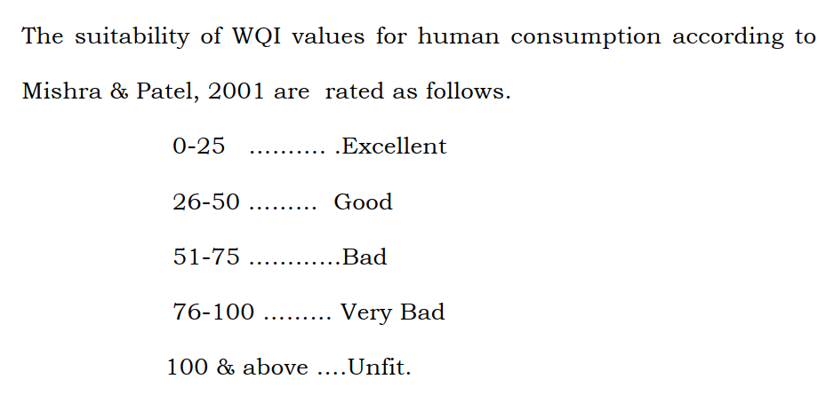

```python
# Displaying the image for the WQI categories
display(Image(filename=r"D:\Data Science\Projects\3. Fuzzy Logic for Water Quality Assessment Project\WQI_ranges.png"))
```

```python
# 4. Membership functions for output (WQI)
wqi['excellent'] = fuzz.trimf(wqi.universe, [0, 15, 30])
wqi['good'] = fuzz.trimf(wqi.universe, [25, 35, 55])
wqi['bad'] = fuzz.trimf(wqi.universe, [50, 65, 80])
wqi['very_bad'] = fuzz.trimf(wqi.universe, [75, 90, 105])
wqi['unfit'] = fuzz.trimf(wqi.universe, [100, 120, 200])
```

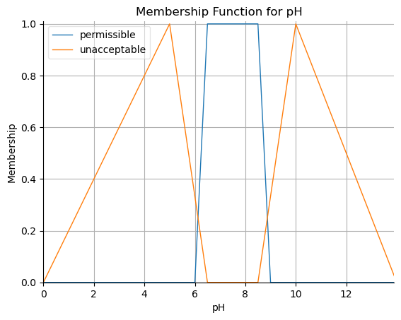

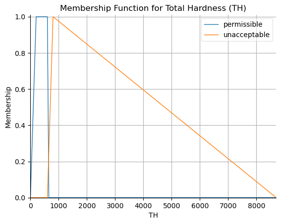

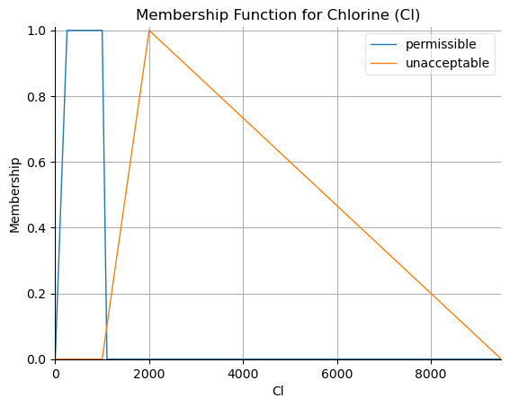

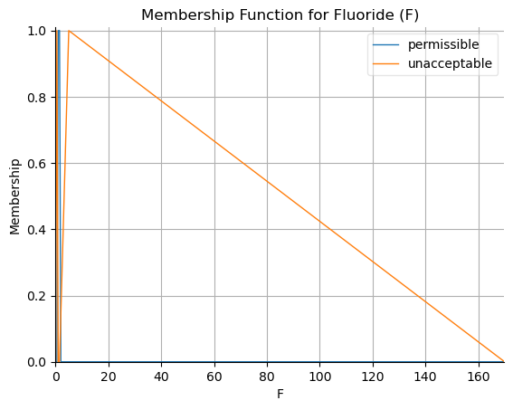

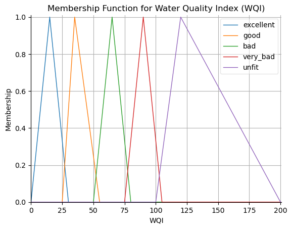

```python
# 5. Visualising all the membership functions

# List of variables and their corresponding titles
variables = [
    (ph, 'Membership Function for pH'),
    (th, 'Membership Function for Total Hardness (TH)'),
    (cl, 'Membership Function for Chlorine (Cl)'),
    (f, 'Membership Function for Fluoride (F)'),
    (wqi, 'Membership Function for Water Quality Index (WQI)')
]

# Loop through each variable and plot
for var, title in variables:
    var.view()
    plt.title(title)
    plt.grid()
    plt.show()
```

### Rules used for classifying WQI category

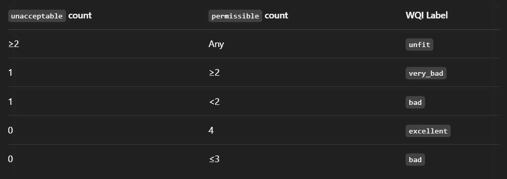

```python
# Displaying the image for the rule base used and alloted WQI category
display(Image(filename=r"D:\Data Science\Projects\3. Fuzzy Logic for Water Quality Assessment Project\WQI_category_rules.png"))
```

```python
# 6. Generate fuzzy rules (based on number of 'permissible' and 'unacceptable' inputs)
from itertools import product

labels = ['permissible', 'unacceptable']
rule_list = []

# Generate combinations for 4 parameters (pH, TH, Cl, F)
combinations = list(product(labels, repeat=4))

for ph_lbl, th_lbl, cl_lbl, f_lbl in combinations:
    status = [ph_lbl, th_lbl, cl_lbl, f_lbl]
    unacc_count = status.count('unacceptable')
    perm_count = status.count('permissible')

    # Final rule logic
    if unacc_count >= 2:
        wqi_lbl = 'unfit'
    elif unacc_count == 1 and perm_count >= 2:
        wqi_lbl = 'very_bad'
    elif unacc_count == 1 and perm_count < 2:
        wqi_lbl = 'bad'
    elif unacc_count == 0 and perm_count == 4:
        wqi_lbl = 'excellent'
    elif unacc_count == 0 and perm_count <= 3:
        wqi_lbl = 'bad'
    else:
        wqi_lbl = 'bad'  # Fallback, though all paths are covered

    # Create fuzzy rule
    rule = ctrl.Rule(
        antecedent=(ph[ph_lbl] & th[th_lbl] & cl[cl_lbl] & f[f_lbl]),
        consequent=wqi[wqi_lbl],
        label=f'Rule_{ph_lbl}_{th_lbl}_{cl_lbl}_{f_lbl}'
    )
    rule_list.append(rule)


# 7. Build the control system and simulation
wqi_ctrl = ctrl.ControlSystem(rule_list)
wqi_sim = ctrl.ControlSystemSimulation(wqi_ctrl)

# 8. Function to compute WQI (Defuzzification)
def compute_wqi(row):
    wqi_sim.reset()
    wqi_sim.input['pH'] = row['pH']
    wqi_sim.input['TH'] = row['TH']
    wqi_sim.input['Cl'] = row['Cl']
    wqi_sim.input['F'] = row['F']
    try:
        wqi_sim.compute()
        return wqi_sim.output['WQI']
    except:
        return np.nan

# 8. Applying the function to our DataFrame
df['WQI'] = df.apply(compute_wqi, axis=1)

# 9. Categorize WQI values
def wqi_category(value):
    if pd.isna(value):
        return 'Unknown'
    elif value <= 25:
        return 'Excellent'
    elif value <= 50:
        return 'Good'
    elif value <= 75:
        return 'Bad'
    elif value <= 100:
        return 'Very Bad'
    else:
        return 'Unfit'

df['WQI_Category'] = df['WQI'].apply(wqi_category)

# 10. Display result
print(df[['pH', 'TH', 'Cl', 'F', 'WQI', 'WQI_Category']])
```

```
        pH      TH      Cl    F         WQI WQI_Category
0      7.9   465.0   120.5  0.5   90.000000     Very Bad
1      7.6   510.0   191.4  0.2   90.000000     Very Bad
2      7.4  1900.0  1201.8  0.1  147.111111        Unfit
3      8.0   425.0   102.8  0.3   90.000000     Very Bad
4      7.8   290.0    24.8  0.2   90.000000     Very Bad
...    ...     ...     ...  ...         ...          ...
13595  7.7   500.0  1077.7  2.0  129.045628        Unfit
13596  7.7  2900.0  5672.0  0.9  143.218423        Unfit
13597  8.1   380.0   567.2  3.8   90.000000     Very Bad
13598  7.6   640.0   581.4  0.8  111.745070        Unfit
13599  8.2   380.0  1843.4  1.2   90.000000     Very Bad

[13600 rows x 6 columns]
```

# Visualization and Inference of Results

```python
category_counts = df['WQI_Category'].value_counts()
category_counts
```

```
WQI_Category
Very Bad     7175
Bad          2078
Excellent    1515
Unfit        1234
Unknown       898
Good          700
Name: count, dtype: int64
```

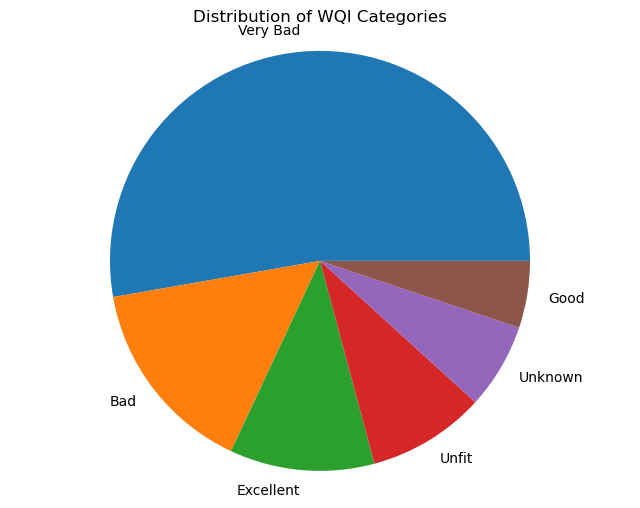

```python
# Plotting pie chart of distribution of WQI categories
plt.figure(figsize=(8, 6))
plt.pie(category_counts, labels=category_counts.index)
plt.title('Distribution of WQI Categories')
plt.axis('equal')  # Equal aspect ratio ensures that pie is drawn as a circle.
plt.show()
```

### Calculating and displaying average WQI of each district

```python
new_df = pd.concat([df_org[['STATE', 'DISTRICT']], df[['WQI', 'WQI_Category']]], axis=1)
new_df.sample(5)
```

|  | STATE | DISTRICT | WQI | WQI_Category |
| --- | --- | --- | --- | --- |
| 13139 | RAJASTHAN | JHALAWAR | 15.000000 | Excellent |
| 4375 | MADHYA PRADESH | RAISEN | 90.000000 | Very Bad |
| 12073 | HARYANA | FARIDABAD | 47.510179 | Good |
| 5629 | U.P | KUSHINAGAR | NaN | Unknown |
| 7406 | TAMIL NADU | VIRUDHUNAGAR | 25.209902 | Good |

```python
district_wqi = new_df.groupby('DISTRICT')['WQI'].mean().reset_index()
district_wqi.columns = ['District', 'Average_WQI']
print(district_wqi)
```

```
             District  Average_WQI
0            ADILABAD    62.526720
1          AGAR MALWA    79.296547
2                AGRA    75.213784
3           AHMEDABAD    99.452542
4          AHMEDNAGAR    89.526042
..                ...          ...
569  WEST KHASI HILLS    90.000000
570      WEST TRIPURA   104.805581
571            YADGIR    68.650935
572       YAMUNANAGAR    85.541603
573          YAVATMAL    68.446700

[574 rows x 2 columns]
```

```python
district_wqi['WQI_Category'] = district_wqi['Average_WQI'].apply(wqi_category)
print(district_wqi.sample(10))
```

```
            District  Average_WQI WQI_Category
423  PURBA MEDINIPUR    87.500000     Very Bad
114      CHITRADURGA    71.268457          Bad
91             BOTAD    88.480390     Very Bad
311             KOTA    63.747898          Bad
221            HOJAI          NaN      Unknown
43       BALODABAZAR    78.323371     Very Bad
98         BURHANPUR    83.714330     Very Bad
464           SANGLI    85.538887     Very Bad
242         JAMNAGAR   101.435557        Unfit
144       DHARMAPURI    78.441759     Very Bad
```

```python
dist_cat_counts = district_wqi['WQI_Category'].value_counts()
dist_cat_counts
```

```
WQI_Category
Very Bad     347
Bad          174
Good          24
Unfit         23
Excellent      3
Unknown        3
Name: count, dtype: int64
```

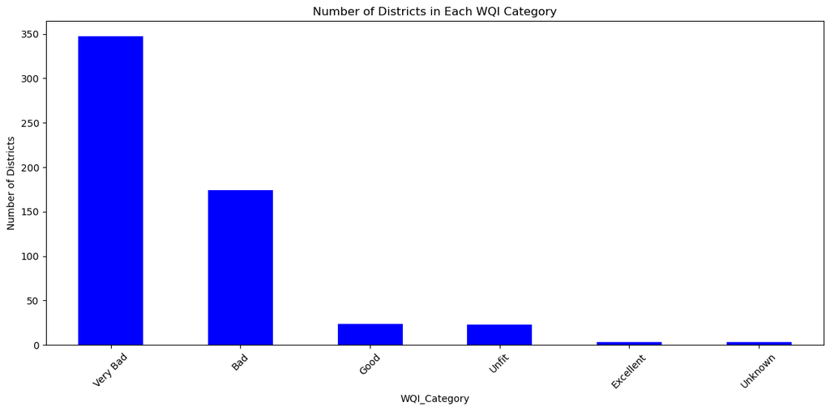

```python
plt.figure(figsize=(12, 6))
dist_cat_counts.plot(kind='bar', color='blue')
plt.ylabel('Number of Districts')
plt.title('Number of Districts in Each WQI Category')
plt.xticks(rotation=45)
plt.tight_layout()
plt.show()
```

### Ranking States based on average WQI

```python
# Group by state and calculate average WQI
state_avg_wqi = new_df.groupby('STATE')['WQI'].mean().reset_index()
state_avg_wqi.columns = ['State', 'Average_WQI']

# Sort in increasing order (lower WQI = better)
state_avg_wqi = state_avg_wqi.sort_values(by='Average_WQI', ascending=True).reset_index(drop=True)

# Assign ranks
state_avg_wqi['Rank'] = state_avg_wqi.index + 1

# Display without index
print(state_avg_wqi.to_string(index=False))
```

```
            State  Average_WQI  Rank
            BIHAR    63.356604     1
        TELANGANA    64.639441     2
      PONDICHERRY    67.610381     3
       TAMIL NADU    71.997137     4
        JHARKHAND    74.100432     5
      MAHARASHTRA    74.104834     6
   MADHYA PRADESH    74.644045     7
   ANDHRA PRADESH    74.700772     8
              U.P    75.226154     9
     CHHATTISGARH    75.557303    10
        KARNATAKA    77.847651    11
        RAJASTHAN    79.644906    12
           PUNJAB    81.133326    13
           ODISHA    82.915814    14
  DADRA AND NAGAR    83.193478    15
ARUNACHAL PRADESH    86.875000    16
      UTTARAKHAND    87.368421    17
            ASSAM    88.590581    18
  JAMMU & KASHMIR    88.933581    19
          TRIPURA    89.811994    20
      WEST BENGAL    89.919057    21
         NAGALAND    90.000000    22
    CHANDIGARH UT    90.000000    23
          HARYANA    90.333180    24
          GUJARAT    91.261179    25
        MEGHALAYA    91.853109    26
           KERALA    94.022272    27
```